# Prova ANOVA (anàlisi de variància)

## Introducció

Aquest document és un resum de com fer una prova d’anàlisi de variància (ANOVA).

## Què és la prova ANOVA

La prova ANOVA és un contrast d’hipòtesi que permet estimar si les diferències en les mitjanes de les mostres de tres grups o més es troben també a les seves respectives poblacions (Agresti, Franklin i Klingenberg 2018, p.8).

Aquesta prova s’anomena “anàlisi de variància” perquè compara la variància d’una variable numèrica entre els diferents grups d’una variable categòrica i la variància dins de cada group. Si la variància entre grups i significativament més gran que la variància dins dels grups, les mitjanes dels grups es declaren com a diferents. Es calcula una ràtio entre les dues variàncies i es compara aquesta ràtio amb un llindar de la distribució de probabilitat de Fisher (distribució *F*).

L’hipòtesi nul·la d’aquest contrast és que les mitjanes entre grups són iguals. L’hipòtesi alternativa, que almenys una mitjana és diferent.

## Dades que farem servir

Fem servir les dades *penguins*. Explorarem la relació en espècies (*k*=3) i la variable massa corporal.

```r
data <- penguins
```

Explorem gràficament la relació entre les dues variables.

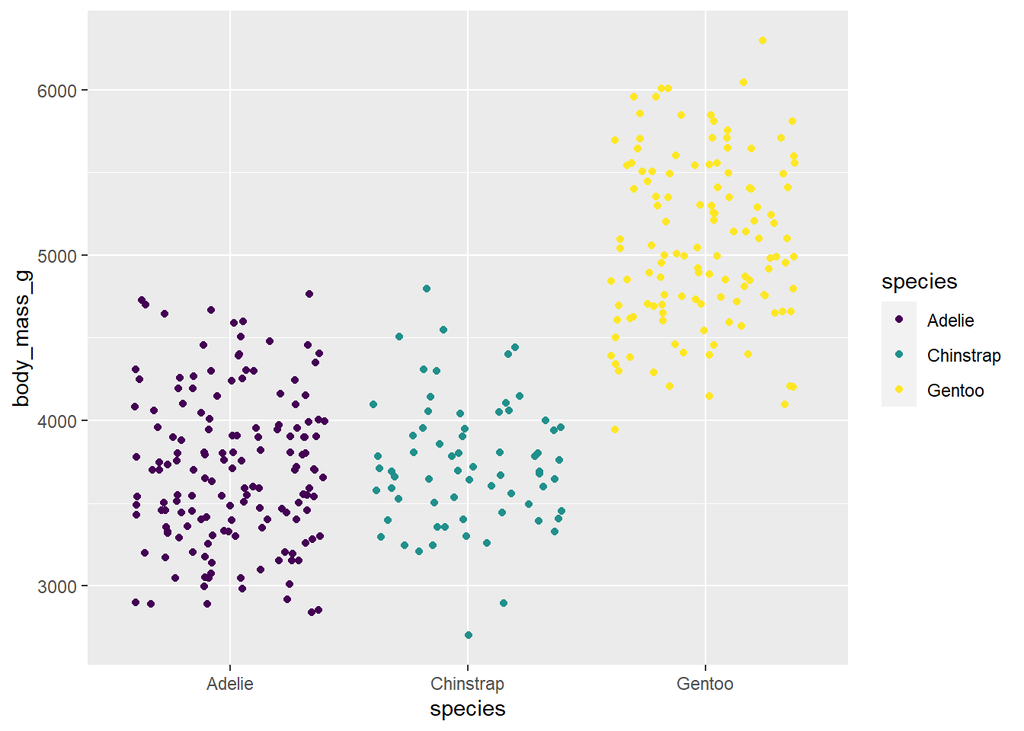

```r
ggplot(data, aes(species, body_mass_g, color=species))+
  geom_jitter()+
  scale_color_manual(values=viridis(3))
```